# Basics of G-quadruplex structures

A quick overview of the (nucleo)bases of G-quadruplex nucleic acids.

Eric Largy https://ericlarg4.github.io/index.html (ARNA)https://arna.cnrs.fr/ , Valérie Gabelica https://gabelicagroup.wixsite.com/biophyms (ARNA)https://arna.cnrs.fr/ , Jean-Louis Mergny  
2020-10-14

# 1. Definitions

In the following section, minimal definitions of terms specific to the field are proposed to ensure a better consistency in describing G-quadruplex structures across publications.

## 1.1 G-quadruplex

G-quadruplex (abbrev.: G4): Secondary structure formed by the association of a minimum of two G-quartets by $\pi$-$\pi$ stacking and coordination to a cation (Figure 1, left). The term G-quadruplex encompasses a variety of conformations differing by their number of G-quartets, loop length and geometry, relative orientation of the G-tract strands, molecularity, and other non-canonical features (e.g. mixed quartets, extended quartets such as hexads or heptads, and additional features including triplets, base pairs or bulges). G-quadruplexes may be formed from nucleic acid having either natural (DNA, RNA) or artificial (e.g. PNA, LNA) backbones.

Tetraplex: Alternative name for G-quadruplex. Not recommended to use it to avoid confusions with other uses of the word (e.g. tetraplex PCR assay). Tetraplex should not be used to imply a tetra-stranded stoichiometry; preferred wording should be: tetramolecular G-quadruplex.

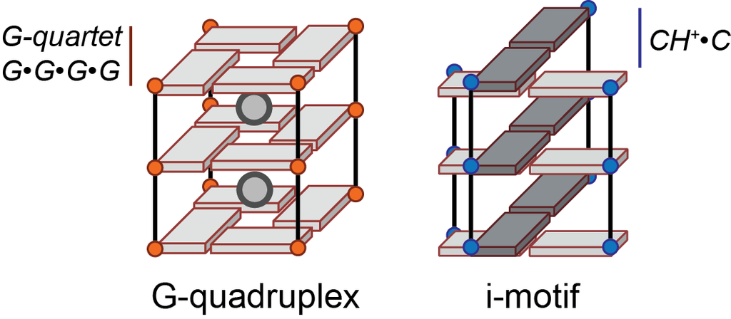

Figure 1: The G-quadruplex and i-motif cores. Both are formed by stacking of different building blocks, respectively the G-quartet and the hemi-protonated cytosine base pair for the i-motif. The phosphate backbone is shown as a line. Guanines and cytosines are depicted by an orange or blue circle, respectively, and a cuboid

Z-G4: Left-handed G-quadruplex, named by analogy with Z-DNA left-handed double helices (DOI: 10.1073/pnas.1418718112).

## 1.2 Quartets and derivatives

G-quartet: Quasi co-planar association of four guanines linked by a network of eight hydrogen bonds on both the Watson-Crick and Hoogsteen faces (i.e. N2H·N7 and N1H·O6) (Figure 2A). They are also frequently called quartets or tetrads, although these terms are less specific and should preferably be avoided.

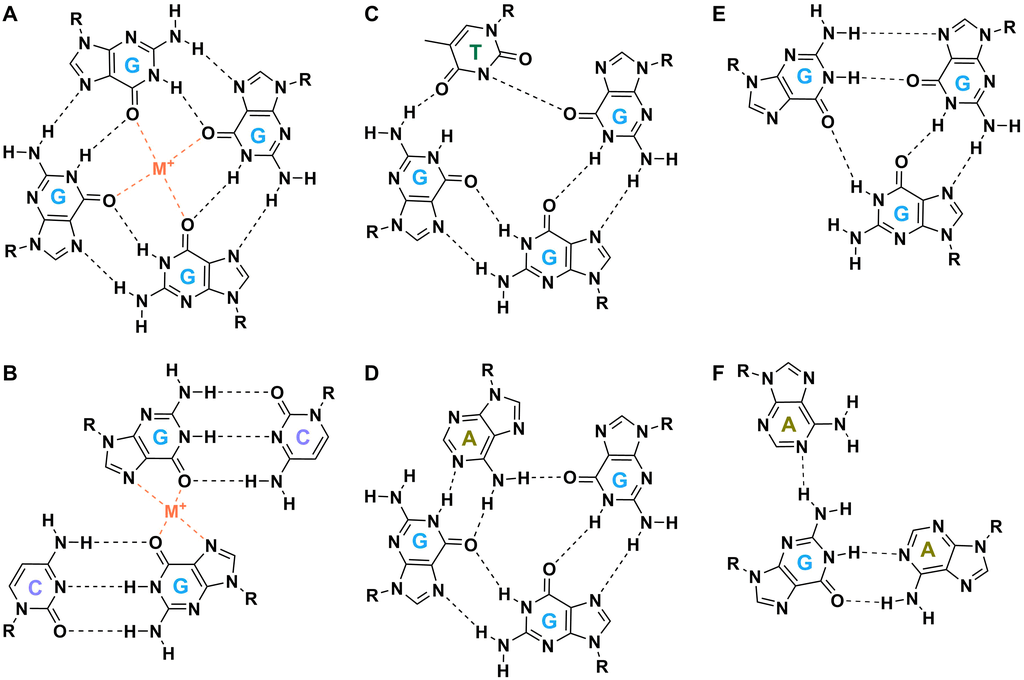

Figure 2: Chemical structures of the G-quartet (A), G·C·G·C (B; DOI: 10.1093/nar/gkp630), G·G·G·T (C; DOI: 10.1021/bi0355185) and G·G·G·A (D; DOI: 10.1021/bi0355185) mixed quartets, G·G·G G-triplet (E; DOI: 10.1093/nar/gkp1029), and A·G·A mixed triplet (F; DOI: 10.1093/nar/gkp1029).

G-tract: Part of a nucleic sequence consisting of a minimum of two consecutive guanines, which may be involved in the formation of *G-quartets* (Figure 3). G-tracts involved in *G-quartet* formation can be interrupted by bulges or snapbacks, and linked to another G-tract by a *loop* (see section 1.3). A minimum of four G-tracts are necessary to form a G-quadruplex, whether they are contained in a single strand or in up to four different strands.

Stem: Consecutively stacked guanines involved in *G-quartet* formation. There are four stems per *core*.

Triplet (or triad): By analogy with the *quartet*, quasi co-planar association of three bases. It can be composed of guanines exclusively (G-triplet; Figure 2E) or *mixed* (Figure 2F).

Base pair: Association of two nucleotides by hydrogen bonding of the bases; not limited to Watson-Crick pairing. Although not typically associated with G-quadruplexes, base pairs can be formed by *loop* and *flanking sequence* nucleotides, and are sometimes stacked upon the *core*, hence contributing to the G4 stabilization.

Core: Structural ensemble of consecutively stacked *quartets* and their *inner cations* (Figure 1). Sometimes called subunits in the context of stacked or interlocked multimers (see section 1.8).

Inner cation: In the particular context of G-quadruplexes, cation bound by the O6 of G-quartets guanines (or related structures, vide supra) (Figures 1 and 2A). Depending on a number of factors including the cation ionic radius and lone pair attraction, cation-cation repulsion, and possible G-quartet distortion, it may be located anywhere from within a *G-quartet*’s plane to – more commonly – midway between two *G-quartets*, as typically observed for potassium (DOI: 10.1007/978-3-319-21756-7).

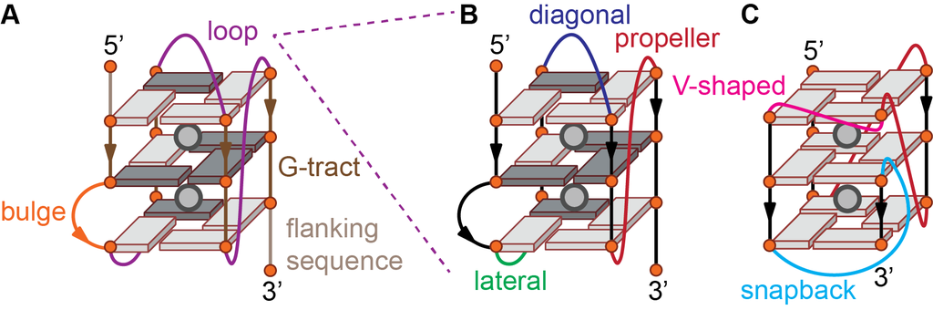

Figure 3: G-quadruplex features beyond the core (A), loop geometries (B), and snapback (C). The phosphate backbone is shown as a line and guanines are depicted by an orange circle and a cuboid in either syn (dark gray) or anti (light gray) conformation.

## 1.3 Beyond the G4 core: loops, bulges, and flanking sequences

Loop: Part of the nucleic acid sequence linking *G-tracts* involved in *G-quartet* formation (Figure 3B). Loops can adopt different geometries (see section 1.4). Loop nucleotides may be *base-paired*.

Bulge: Part of a sequence interrupting a *G-tract* involved in *G-quartet* formation, *i.e.* nucleotides linking two guanines implicated in two consecutively stacked *G-quartets* (Figure 3A).

Flanking sequence: Nucleotides from the 5’- and 3’-termini of a G-quadruplex positioned before the first or after the last *G-quartet* forming guanine, respectively (Figure 3A). *Flanking sequence* nucleotides may be *base-paired*. Although not part of the *core*, flanking sequences can have a large impact on the topology and multimerization of G-quadruplexes (DOI: 10.1021/jacs.5b13130). Flanking sequences are naturally present in the genomic context.

## 1.4 Loop types

Propeller (or chain reversal): *loop* spanning across *G-quartets* to connect guanines from two different *quartets* so that the two linked *G-tracts* are adjacent and share the same 5’-3’ polarity (parallel) (Figure 3B). Parallel loops typically contain 1—2 nucleotides.

V-shaped: Variant of the *propeller* loop that does not contain any nucleotide, so that the two *G-tracts* are directly connected.

Lateral or edgewise: loop connecting two adjacent *G-tracts* of opposite 5’-3’ polarity (*antiparallel*) (Figure 3B). Lateral loops typically contain at least 2—3 nucleotides depending on the *groove* width.

Diagonal: loop linking diagonally opposed G-tracts of opposite 5’-3’ polarity (antiparallel) (Figure 3B). Diagonal loops typically contain at least 3 nucleotides.

Snapback: Loop that connects an external *quartet* to an internal *quartet*., instead of linking two external quartets as more commonly observed. This means that one *stem* of consecutively stacked guanines is composed of two distinct *G-tracts* (Figure 3C) (DOI: 10.1021/ja068739h). This implies that the *stem* in question is not composed of a continuous phosphate backbone.

Both *lateral* and *diagonal* loops result in a strand polarity inversion occurring in *antiparallel* and *hybrid* topologies, whereas *propeller* loops preserve the same orientation and are thus found only in *parallel* and *hybrid* topologies (see section 1.6).